# Homework 6

Victor Aluko

2 April 2017

## Exercise 1

The plot of the data is displayed below:

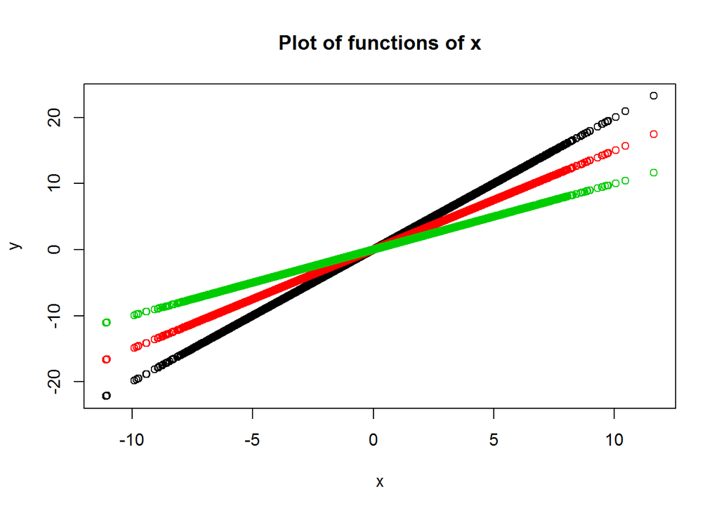

```r
Calc_funcs <- function(a, b) {
  data.frame(x = a, y = b,
             yx = a, y15x = 1.5 * a,
             y2x = 2 * a)
}

generated_Data <- do.call(rbind, apply(xydata, 1, function(ab) Calc_funcs(ab['x'], ab['y'])))

plot(generated_Data$x, generated_Data$y2x, type = "p", main = "Plot of functions of x", ylab = "y", xlab = "x")
points(generated_Data$x, generated_Data$y15x, col=2)
points(generated_Data$x, generated_Data$yx, col=3)
```

The RMSE values for the 3 formulas are given below, calculated using the respective R code

```r
RMSE_yx <- sqrt(mean((generated_Data$yx - generated_Data$y)^2))
RMSE_yx
```

```
## [1] 4.274423
```

```r
RMSE_y15x <- sqrt(mean((generated_Data$y15x - generated_Data$y)^2))
RMSE_y15x
```

```
## [1] 4.017965
```

```r
RMSE_y2x <- sqrt(mean((generated_Data$y2x - generated_Data$y)^2))
RMSE_y2x
```

```
## [1] 4.300501
```

The Root Mean Squared Error value describes how much the values of the second dataset vary from the reference dataset. In this case, y is our reference dataset. The 3 formulas, y = x, y = 1.5x and y = 2x, are the generated dataset to be used for comparison with the x-y dataset. From the calculated results for RMSE, we see how much the formulas vary from the x-y dataset.

Based on the RMSE values, we can infer that y = 1.5x gives a good description of the data as it has the minimum variance value from the values of y. This shows us that taking y as the predicted value, the formular y = 1.5x varies the least from its values than y = x and y = 2x. y = x and y = 2x produce higher RMSE values, which means they vary more from the reference data set.

## Exercise 2

For the dataset, I decided to generate the linear regression model starting from the first column to the last column. That is fixed.acidity to alcohol. The Coefficient values are listed below:

| Column name | Coefficient | Adjusted R-squared |
| --- | --- | --- |
| fixed.acidity | 3.34e-07 | 0.01556 |
| Volatile.acidity | 2e-16 | 0.1416 |
| citric.acid | 2.2e-16 | 0.04783 |
| residual.sugar | 0.4082 | -0.0001975 |
| chlorides | 1.297e-06 | 0.01395 |
| free.sulfur.dioxide | 0.0513 | 0.001752 |
| total.sulfur.dioxide | 1.092e-12 | 0.03063 |
| density | 2.961e-11 | 0.0267 |
| pH | 0.01324 | 0.003213 |
| sulphates | 2.2e-16 | 0.05224 |
| alcohol | 2.2e-16 | 0.2019 |

Given the threshold of 0.05, We can see thatonly residual.sugar and free.sulfur.dioxide produce coefficient greater than the threshold

The Adjusted R=squared values are also indicated below. Only residual.sugar has a negative value R-squared.

## Exercise 3

For this exercise, I’ll use the Petal.length for versicolor and setosa flower types. I will check if the feature means of the 2 flower types differ or are equal.

The result using the t.test function shows that mean of versicolor is greater than mean of setosa

```r
data("iris")
iris_setosa = subset(iris, Species == "setosa")
iris_versicolor = subset(iris, Species == "versicolor")
t_result <- t.test(iris_setosa$Petal.Length, iris_versicolor$Petal.Length, alternative = "greater")
t_result
```

```
##
##  Welch Two Sample t-test
##
## data:  iris_setosa$Petal.Length and iris_versicolor$Petal.Length
## t = -39.493, df = 62.14, p-value = 1
## alternative hypothesis: true difference in means is greater than 0
## 95 percent confidence interval:
##  -2.916299       Inf
## sample estimates:
## mean of x mean of y
##     1.462     4.260
```

By manual calculation, I had to first calculate the t statistics value. This involved calculating the mean, standard deviation and square root of the length of the data set. I then used the T value to calculate the p-value, using the t-distribution function. I used the absolute value of the t-values in the t-distribution function because not doing so would have given me a p-value greater than 1, which would have been in accurate

The p-value for setosa is 8.80572344834089e-85

```r
setosa_t.value = (mean(iris_setosa$Petal.Length) - 10) / (sd(iris_setosa$Petal.Length) / sqrt(length(iris_setosa$Petal.Length)))
setosa_p.value = 2*pt(-abs(setosa_t.value), df=length(iris_setosa$Petal.Length)-1)
```

while the p-value for versicolor is 3.26178708455119e-55

```r
versicolor_t.value = (mean(iris_versicolor$Petal.Length) - 10) / (sd(iris_versicolor$Petal.Length) / sqrt(length(iris_versicolor$Petal.Length)))
versicolor_p.value = 2*pt(-abs(versicolor_t.value), df=length(iris_versicolor$Petal.Length)-1)
```

Based on these results, the p-value of the 2 flower types are different. This also agrees with the calculation by t.test that the mean of versicolor is greater than mean of setosa